# VVnA R Package

Aous Abdo

Tuesday, August 12, 2014

# Introduction

# Functions

## Projectile Motion

Projectile motion in vacuum and in air are calculated with the `projectile` and `projFrictionLin` functions respectively. when considering air friction effects on projectiles, we only consider the viscous drag which is related to the velocity `v`. The Inertial drag realted to the square of the velocity is not treated in this package.

In each of these two cases, a function will return the following projectile parameters:

1. `x`: Displacement in the horizontal direction as a function of time (in meters)
2. `vx`: Speed in the horizontal direction as a function of time (in m/s units)
3. `y`: Displacement in the vertical direction as a function of time (in meters)
4. `vy`: Speed in the vertical direction as a function of time (in m/s units)
5. `y_x`: Displacement in the vertical direction as a function of horizontal displacement (in meters)

In all cases, it is assumed that there are no motion in the lateral direction.

### Projectile Motion in Vaccum

Arguments of the `projectile` function are:

1. `v0`: Initial velocity in m/s
2. `y0`: Initial height in m
3. `theta0`: Initial angle in degrees
4. `t`: Time of flight in seconds

For vectors of length `1` for all arguments, the function will return a list of projectile parameters for those arguments. For example for an initial velocity `v` of `30 m/s`, initial height `y` of `0 m`, initial projectile angle `theta0` of `30 degrees`, and at time `t=3 seconds` we get:

```r
projectile(t = 3, y0 = 0, v0 = 30, theta0 = 30)
```

```
## $x
## [1] 77.94
##
## $vx
## [1] 25.98
##
## $y
## [1] 0.9
##
## $vy
## [1] -14.4
##
## $y_x
## [1] 0.9
```

One can also pass a vector of length `> 1` for any individual input parameter. This is most useful for the time parameter `t`:

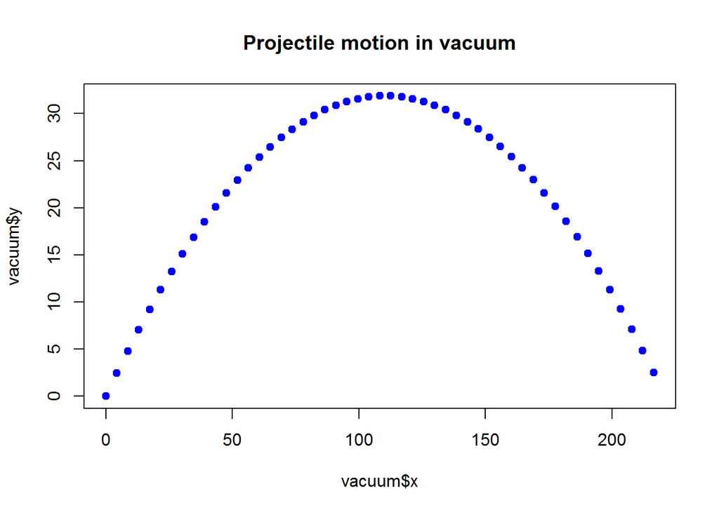

```r
vacuum <- projectile(t = seq(0,5,0.1), y0 = 0, v0 = 50, theta0 = 30)
plot(vacuum$x, vacuum$y, pch=19, col="blue", main="Projectile motion in vacuum")
```

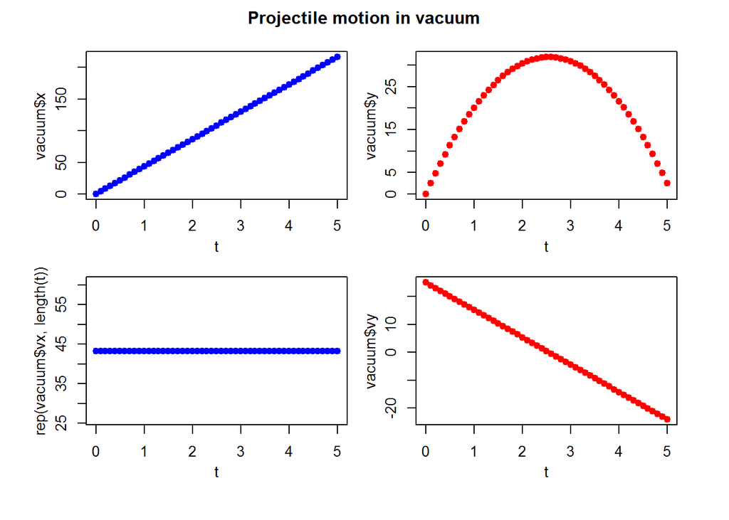

```r
t <- seq(0,5,0.1)
vacuum <- projectile(t = t, y0 = 0, v0 = 50, theta0 = 30)
## prepare grid
par(mfcol=c(2,2), mar = c(3.5,3,1,1), oma=c(2,2,2,2), mgp=c(2.2,1,0))
## plot outputs
plot(t, vacuum$x, pch=19, col="blue")
plot(t, rep(vacuum$vx, length(t)), pch=19, col="blue")
plot(t, vacuum$y, pch=19, col="red")
plot(t, vacuum$vy, pch=19, col="red")
title("Projectile motion in vacuum", outer=TRUE)
```

### Projectile Motion in Air

Arguments of the `projFrictionLin` function are:

1. `v0`: Initial velocity in m/s
2. `y0`: Initial height in m
3. `theta0`: Initial angle in degrees
4. `t`: Time of flight in seconds
5. `b`: drag coefficient in Newtons.seconds/meters
6. `m` mass of object in kg

For vectors of length `1` for all arguments, the function will return a list of projectile parameters for those arguments. For example for an initial velocity `v` of `30 m/s`, initial height `y` of `0 m`, initial projectile angle `theta0` of `30 degrees`, drag coeffiecient `b` of 0.5, mass of projectile `m` of 5 kg, and at time `t=3 seconds` we get:

```r
projFrictoinLin(t = 3, y0 = 0, v0 = 30, theta0 = 30, b = 0.5, m = 5)
```

```
## $x
## [1] 67.34
##
## $vx
## [1] 19.25
##
## $y
## [1] -1.125
##
## $vy
## [1] -14.29
##
## $y_x
## [1] -1.125
```

One can also pass a vector of length `> 1` for any individual input parameter. This is most useful for the time parameter `t`:

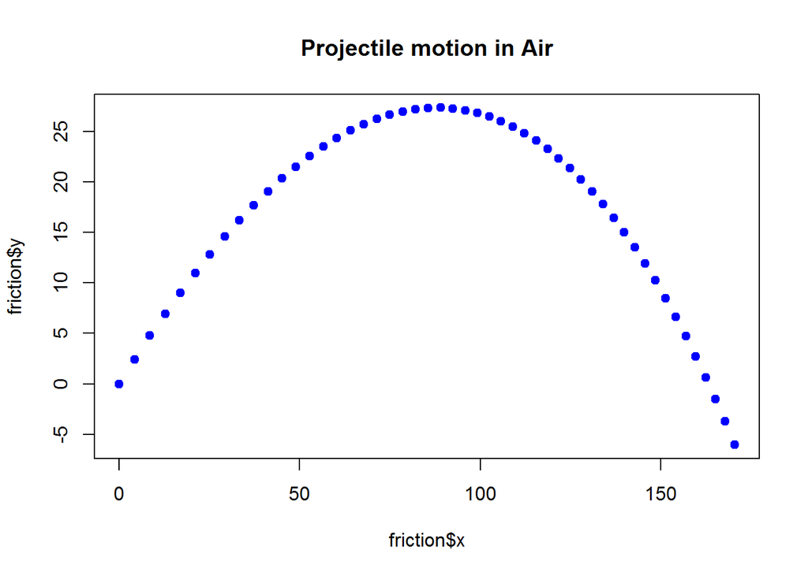

```r
friction <- projFrictoinLin(t = seq(0,5,0.1), y0 = 0, v0 = 50, theta0 = 30, b = 0.5, m = 5)
plot(friction$x, friction$y, pch=19, col="blue", main="Projectile motion in Air")
```

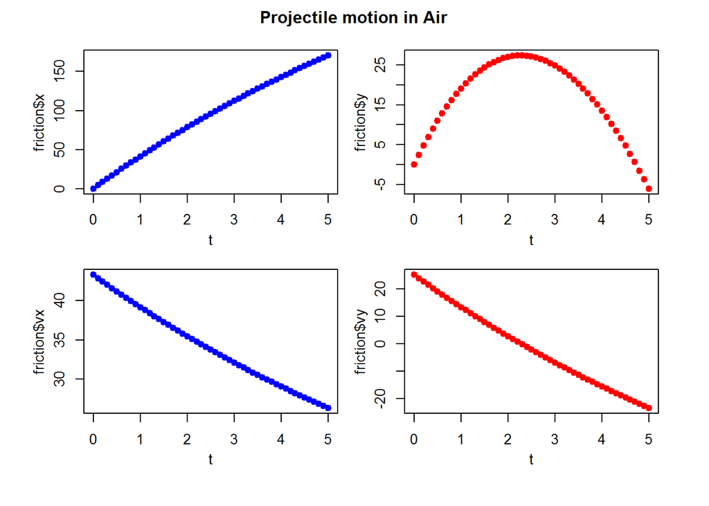

```r
t <- seq(0,5,0.1)
friction <- projFrictoinLin(t = t, y0 = 0, v0 = 50, theta0 = 30, b = 0.5, m = 5)
## prepare grid
par(mfcol=c(2,2), mar = c(3.5,3,1,1), oma=c(2,2,2,2), mgp=c(2.2,1,0))
## plot outputs
plot(t, friction$x, pch=19, col="blue")
plot(t, friction$vx, pch=19, col="blue")
plot(t, friction$y, pch=19, col="red")
plot(t, friction$vy, pch=19, col="red")
title("Projectile motion in Air", outer=TRUE)
```